**An Analysis on the prediction of car crashes** In todays world, most of us of age 18 and older have cars. But with such great responsibility comes great risks. Car crashes are very prominent in today's day and age with lots of factors coming into play. Some of those factors include Weather, Time of the day driving, Driver Experience, Road Condition and many more. My project contains a dataset from https://www.kaggle.com/datasets/denkuznetz/traffic-accident-prediction which will help me analyze and predict the chances of a car crash based on circumstances.

Analyzing brings me to ask the following questions:

- How does traffic density affect accidents?
- Does weather affect Accident rates?
- Does alcohol play a role in the rate of crashes?
- Is it safer to drive in Daylight or Nightime?
- Does road condition play a role in Car crashes?
- Does road type influence crashes ?

```python
import pandas as pd
import matplotlib.pyplot as plt
import seaborn as sns
```

```python
data = pd.read_csv('dataset_traffic_accident_prediction1.csv')
```

```python
data.head()
```

|  | Weather | Road_Type | Time_of_Day | Traffic_Density | Speed_Limit | Number_of_Vehicles | Driver_Alcohol | Accident_Severity | Road_Condition | Vehicle_Type | Driver_Age | Driver_Experience | Road_Light_Condition | Accident |
| --- | --- | --- | --- | --- | --- | --- | --- | --- | --- | --- | --- | --- | --- | --- |
| 0 | Rainy | City Road | Morning | 1.0 | 100.0 | 5.0 | 0.0 | NaN | Wet | Car | 51.0 | 48.0 | Artificial Light | 0.0 |
| 1 | Clear | Rural Road | Night | NaN | 120.0 | 3.0 | 0.0 | Moderate | Wet | Truck | 49.0 | 43.0 | Artificial Light | 0.0 |
| 2 | Rainy | Highway | Evening | 1.0 | 60.0 | 4.0 | 0.0 | Low | Icy | Car | 54.0 | 52.0 | Artificial Light | 0.0 |
| 3 | Clear | City Road | Afternoon | 2.0 | 60.0 | 3.0 | 0.0 | Low | Under Construction | Bus | 34.0 | 31.0 | Daylight | 0.0 |
| 4 | Rainy | Highway | Morning | 1.0 | 195.0 | 11.0 | 0.0 | Low | Dry | Car | 62.0 | 55.0 | Artificial Light | 1.0 |

```python
data.info()
```

```
<class 'pandas.core.frame.DataFrame'>
RangeIndex: 840 entries, 0 to 839
Data columns (total 14 columns):
 #   Column                Non-Null Count  Dtype
---  ------                --------------  -----
 0   Weather               798 non-null    object
 1   Road_Type             798 non-null    object
 2   Time_of_Day           798 non-null    object
 3   Traffic_Density       798 non-null    float64
 4   Speed_Limit           798 non-null    float64
 5   Number_of_Vehicles    798 non-null    float64
 6   Driver_Alcohol        798 non-null    float64
 7   Accident_Severity     798 non-null    object
 8   Road_Condition        798 non-null    object
 9   Vehicle_Type          798 non-null    object
 10  Driver_Age            798 non-null    float64
 11  Driver_Experience     798 non-null    float64
 12  Road_Light_Condition  798 non-null    object
 13  Accident              798 non-null    float64
dtypes: float64(7), object(7)
memory usage: 92.0+ KB
```

# QUESTION 1: HOW DOES TRAFFIC DENSITY AFFECTS ACCIDENTS?

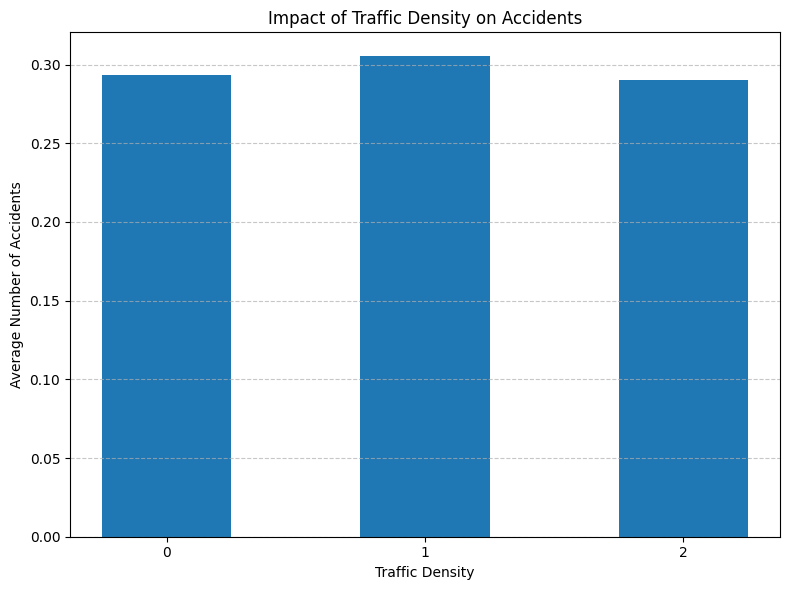

```python
data = pd.read_csv('dataset_traffic_accident_prediction1.csv')

# Grouping data by Traffic Density and calculating average accidents
traffic_density_accidents = data.groupby('Traffic_Density')['Accident'].mean().reset_index()

# Plotting the results
plt.figure(figsize=(8, 6))
plt.bar(traffic_density_accidents['Traffic_Density'], traffic_density_accidents['Accident'], width=0.5)
plt.xlabel('Traffic Density')
plt.ylabel('Average Number of Accidents')
plt.title('Impact of Traffic Density on Accidents')
plt.xticks(traffic_density_accidents['Traffic_Density'])
plt.grid(axis='y', linestyle='--', alpha=0.7)
plt.tight_layout()
plt.show()
```

### Based on my analysis and Plotting, Traffic density does not seem to play an important role in the causation of accidents. Which if you think about it, makes sense because when there is more traffic, people tend to be more alert reducing the amount of crashes.

# Q2:Does weather affect Accident rates?

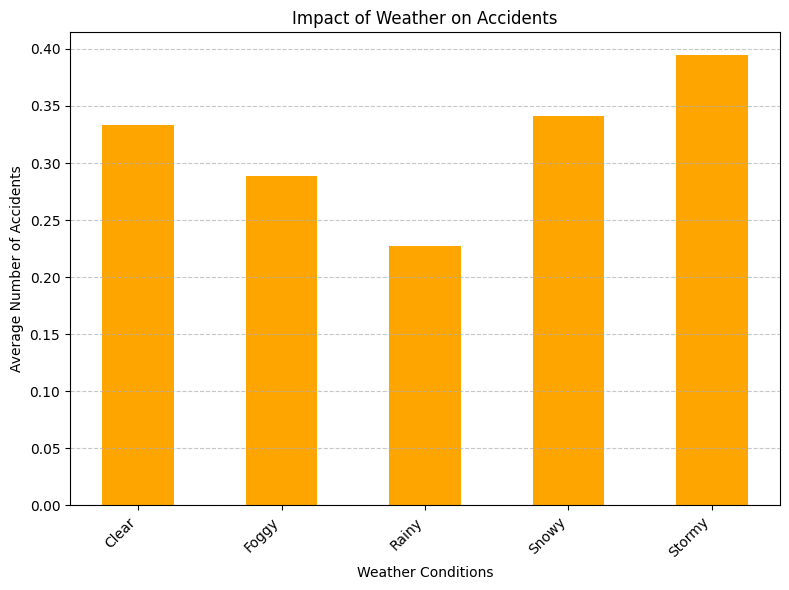

```python
data = pd.read_csv('dataset_traffic_accident_prediction1.csv')
weather_accidents = data.groupby('Weather')['Accident'].mean().reset_index()

# Plotting the results
plt.figure(figsize=(8, 6))
plt.bar(weather_accidents['Weather'], weather_accidents['Accident'], color='orange', width=0.5)
plt.xlabel('Weather Conditions')
plt.ylabel('Average Number of Accidents')
plt.title('Impact of Weather on Accidents')
plt.xticks(rotation=45, ha='right')
plt.grid(axis='y', linestyle='--', alpha=0.7)
plt.tight_layout()
plt.show()
```

### Analysis :Clear weather has a high rate of Accidents and this leads me to believe it is because most drivers are overconfident when driving in Pleasant weather. However, storms have the highest average number of crashes and this leads me to believe it is because unexpected things happen and stormy weather, the roads are very slick and slippery visibility is low and so much more stuff which is unexpected. Raininess is the lowest and this leads me to believe it is because most drivers are cautious when it starts to rain. So in conclusion I believe weather definitely plays A Part in the amount of crashes, but it all boils down to how alert the driver is.

# Q3: Does alcohol play a role in the rate of crashes?

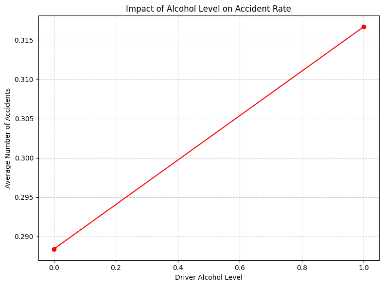

```python
alcohol_accidents = data.groupby('Driver_Alcohol')['Accident'].mean().reset_index()

# Plotting the results
plt.figure(figsize=(8, 6))
plt.plot(alcohol_accidents['Driver_Alcohol'], alcohol_accidents['Accident'], marker='o', linestyle='-', color='red')
plt.xlabel('Driver Alcohol Level')
plt.ylabel('Average Number of Accidents')
plt.title('Impact of Alcohol Level on Accident Rate')
plt.grid(axis='both', linestyle='--', alpha=0.7)
plt.tight_layout()
plt.show()
```

# Q4: Is it safer to drive in Daylight or Nightime?

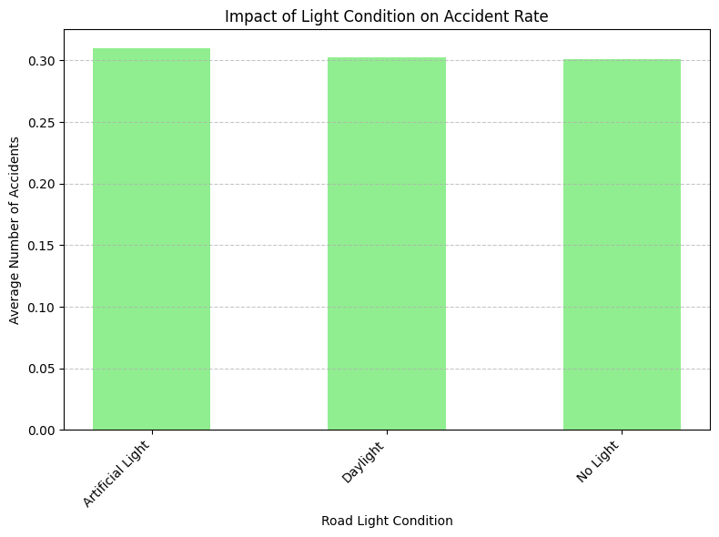

```python
# Grouping data by Road Light Condition and calculating average accidents
light_condition_accidents = data.groupby('Road_Light_Condition')['Accident'].mean().reset_index()

# Plotting the results
plt.figure(figsize=(8, 6))
plt.bar(light_condition_accidents['Road_Light_Condition'], light_condition_accidents['Accident'], color='lightgreen', width=0.5)
plt.xlabel('Road Light Condition')
plt.ylabel('Average Number of Accidents')
plt.title('Impact of Light Condition on Accident Rate')
plt.xticks(rotation=45, ha='right')
plt.grid(axis='y', linestyle='--', alpha=0.7)
plt.tight_layout()
plt.show()
```

### There is almost no difference in the average number of crashes whether there is daylight, no light or artificial light. This leads me to believe it is because drivers pay attention and are focused on the road regardless of what time of the day it is. But if we pay attention, the amount of crashes in artificial light is slightly higher, and I believe this is due to the blinding effect of light. for example driving towards another car at night with high beams on. That signinficantly increases the risk for a crash In conclusion most drivers remain focused on the road regardless of light.

# Q5: Does road condition play a role in Car crashes?

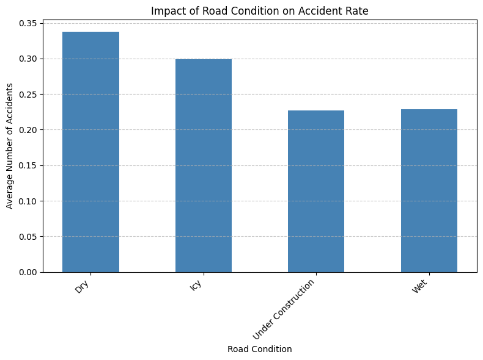

```python
road_condition_accidents = data.groupby('Road_Condition')['Accident'].mean().reset_index()

# Plotting the results
plt.figure(figsize=(8, 6))
plt.bar(road_condition_accidents['Road_Condition'], road_condition_accidents['Accident'], color='steelblue', width=0.5)
plt.xlabel('Road Condition')
plt.ylabel('Average Number of Accidents')
plt.title('Impact of Road Condition on Accident Rate')
plt.xticks(rotation=45, ha='right')
plt.grid(axis='y', linestyle='--', alpha=0.7)
plt.tight_layout()
plt.show()
```

### Dry has the highest rate of crashes most definitely due to over confidence and speeding

# Q6: Does Road type influence crashes

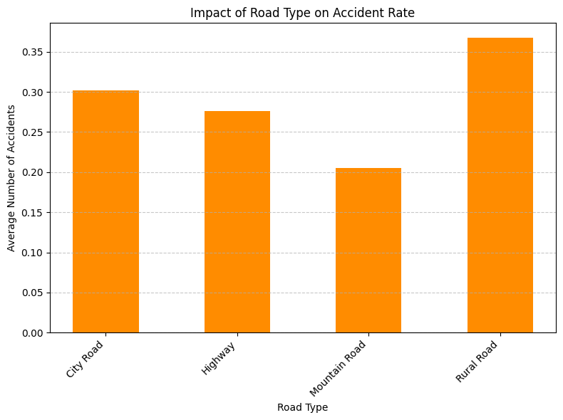

```python
road_type_accidents = data.groupby('Road_Type')['Accident'].mean().reset_index()

# Plotting the results
plt.figure(figsize=(8, 6))
plt.bar(road_type_accidents['Road_Type'], road_type_accidents['Accident'], color='darkorange', width=0.5)
plt.xlabel('Road Type')
plt.ylabel('Average Number of Accidents')
plt.title('Impact of Road Type on Accident Rate')
plt.xticks(rotation=45, ha='right')
plt.grid(axis='y', linestyle='--', alpha=0.7)
plt.tight_layout()
plt.show()
```

Road type plays a role in the causation of crashes. Let me elaborate based on the data, Rural roads have the highest average number of accidents and that leads me to believe it is because of the high rates of speeds usually taken on those roads due to lesser traffic and sometimes the conditions of these roads are poor. Mountain road has the least average crash rate most likely due to very little traffic going to those areas. City road is high most definitely due to overconfidence and blatantly speeding. And highway most definitely because of speed.

In conclusion the road type influences crashes with most happening on rural roads.